# Daily_measurements

PutnamLab

7/19/2022

This script plots daily measurements from the CBLS Wet lab for the Putnam lab. Run this script daily after daily measurements are taken and inputted into the datasheet.

Script updated 11/14/23 by ZD. Script updated 11/16/23 by JA - added upper and lower threshold lines on plots.

Script updated 1/2/24 by JA. Added probe set to daily df so that pH is calculated based on the probe set. The data is then merged back together for the plots.

Script updated 3/11/24 by DMB. Added total alkalinity plots and upper and lower threshold lines for TA.

Script updated 9/14/24 by ZD to set Probe Set #2 as probe set for QT.

Script updated 1/30/25 by ZD to add Calcium DMs. Script updated 3/6/25 by ZD to add Alkalinity dkH measurements.

## Load data

```r
## Read in data
daily <- read.csv("../Data/Daily_measurements_tracking.csv")
head(daily)
```

```
##       Date         Tank_ID Time Date.Time Observer.Initials Temperature_C pH_mv
## 1 20220117     header_tank             NA                              NA    NA
## 2 20220117 quarantine_tank             NA                           23.88    NA
## 3 20220117      blue_tank1             NA                           25.91    NA
## 4 20220117      blue_tank2             NA                           25.91    NA
## 5 20220117      blue_tank3             NA                           25.95    NA
## 6 20220117      blue_tank4             NA                           25.91    NA
##   Salinity_psu Calcium_ppm TA_dKH Orion_Temp light2 light3 light4 tris.date
## 1           NA          NA     NA         NA     NA     NA   <NA>  20210816
## 2        34.12          NA     NA         NA     91     75     71  20210816
## 3        36.62          NA     NA         NA     68     54     55  20210816
## 4        36.57          NA     NA         NA     70     48     51  20210816
## 5        36.53          NA     NA         NA     52     72     61  20210816
## 6        36.55          NA     NA         NA     79     56     51  20210816
##   Probe.Set                                     notes
## 1           Pierrick cleaned and constructed new flow
## 2
## 3
## 4
## 5
## 6
```

```r
tail(daily) # check to make sure data from today is there
```

```
##          Date     Tank_ID  Time Date.Time Observer.Initials Temperature_C pH_mv
## 2797 20250429 header_tank 09:30        NA                SS         24.03 -49.0
## 2798 20250429      BT 1/2 09:30        NA                SS         24.01 -51.7
## 2799 20250429      BT 3/4 09:30        NA                SS         24.08 -51.8
## 2800 20250430 header_tank 11:30        NA                              NA    NA
## 2801 20250430      BT 1/2 11:30        NA                              NA    NA
## 2802 20250430      BT 3/4 11:30        NA                              NA    NA
##      Salinity_psu Calcium_ppm TA_dKH Orion_Temp light2 light3 light4 tris.date
## 2797        33.97          NA     NA         NA     NA     NA   <NA>  20250327
## 2798        34.01       323.6     NA         NA     NA     NA   <NA>  20250327
## 2799        34.03          NA     NA         NA     NA     NA   <NA>  20250327
## 2800           NA          NA     NA         NA     NA     NA   <NA>  20250327
## 2801           NA          NA     NA         NA     NA     NA   <NA>  20250327
## 2802           NA          NA     NA         NA     NA     NA   <NA>  20250327
##      Probe.Set notes
## 2797    Probe1
## 2798    Probe1
## 2799    Probe1
## 2800    Probe1
## 2801    Probe1
## 2802    Probe1
```

```r
## Swap blue_tank1 and 2 for BT 1/2
daily$Tank_ID <- ifelse(daily$Tank_ID == "blue_tank1" | daily$Tank_ID == "blue_tank2", "BT 1/2", daily$Tank_ID)

## Swap blue_tank3 and 4 for BT 3/4
daily$Tank_ID <- ifelse(daily$Tank_ID == "blue_tank3" | daily$Tank_ID == "blue_tank4", "BT 3/4", daily$Tank_ID)

## Swap quarantine_tank for QT
daily$Tank_ID <- ifelse(daily$Tank_ID == "quarantine_tank", "QT", daily$Tank_ID)

# Load TA measurements data
TA <- read.csv("../Data/CBLS_Aquarium_TA.csv")

# Rename the "SampleID" column to "Tank_ID"
TA.mod <- TA %>%
  rename(Tank_ID = SampleID)

# Filter rows for specific Tank_ID values ("header_tank", "BT 1/2", "BT 3/4")
selected_tanks <- c("header_tank", "BT 1/2", "BT 3/4", "QT")
filtered_data <- TA.mod %>%
  filter(Tank_ID %in% selected_tanks)

# Select only the desired columns
filtered_data_subset <- filtered_data %>%
  select(Date, Tank_ID, TA)
```

Set dates as characters (needs to be done for merging with the tris calibration file)

```r
daily$Date <- as.character(daily$Date)
filtered_data_subset$Date <- as.character(filtered_data_subset$Date)
daily$tris.date <- as.character(daily$tris.date)
```

Combine TA data frame and daily measurments

```r
daily <- merge(daily, filtered_data_subset, by = c("Date", "Tank_ID"), all.x = TRUE)
```

Probe Set 1 (for the header, all corals, and for the non-quarantine tank) e.g., BT 3/4 and header tank and salt mixing tank

```r
daily.probe1 <- daily %>%
  filter(Probe.Set == "Probe1")

range(na.omit(daily.probe1$Temperature_C))
```

```
## [1] 22.220 26.906
```

```r
range(na.omit(daily.probe1$pH_mv))
```

```
## [1] -75.8 -38.0
```

```r
range(na.omit(daily.probe1$Salinity_psu))
```

```
## [1] 32.93 41.36
```

```r
daily.probe2 <- daily %>%
  filter(Probe.Set == "Probe2")

range(na.omit(daily.probe2$Temperature_C))
```

```
## [1] 22.25 26.48
```

```r
range(na.omit(daily.probe2$pH_mv))
```

```
## [1] -76 -44
```

```r
range(na.omit(daily.probe2$Salinity_psu))
```

```
## [1] 34.23 36.13
```

## Calculate total pH from Probe Set 1

Calculate the calibration curve from the Tris calibration and calculate pH on the total scale from pH.mV.

```r
pHcalib<-read_csv("../Data/Tris_Calibration.csv")
```

```r
pHcalib$tris.date<-as.character(pHcalib$tris.date)

pHSlope.probe1 <- pHcalib %>%
  group_by(tris.date) %>%
  nest() %>%
  mutate(fitpH = map(data, ~ lm(mVTris ~ TTris, data = .x))) %>%
  mutate(tidy_fit = map(fitpH, broom::tidy)) %>%
  unnest(tidy_fit) %>%
  select(tris.date, term, estimate) %>%
  pivot_wider(names_from = term, values_from = estimate) %>%
  left_join(daily.probe1, ., by = "tris.date") %>%
  mutate(mVTris = Temperature_C * TTris + `(Intercept)`)

# range(pHSlope.probe1$Temperature_C)
# pHSlope.probe1 <- pHSlope.probe1 %>% filter(!is.na(Temperature_C))
# range(pHSlope.probe1$Temperature_C)
#
# range(pHSlope.probe1$pH_mv)
# pHSlope.probe1 <- pHSlope.probe1 %>% filter(!is.na(pH_mv))
# range(pHSlope.probe1$pH_mv)
#
# range(pHSlope.probe1$Salinity_psu)
# pHSlope.probe1 <- pHSlope.probe1 %>% filter(!is.na(Salinity_psu))
# range(pHSlope.probe1$Salinity_psu)
#
# range(pHSlope.probe1$pH_mv)
# pHSlope.probe1 <- pHSlope.probe1 %>% filter(!is.na(pH_mv))
# range(pHSlope.probe1$pH_mv)
#
# range(pHSlope.probe1$mVTris)
# pHSlope.probe1 <- pHSlope.probe1 %>% filter(!is.na(mVTris))
# range(pHSlope.probe1$mVTris)

pHSlope.probe1 <- pHSlope.probe1 %>%
  mutate(pH.total = seacarb::pH(Ex = pH_mv, Etris = mVTris, S=Salinity_psu, T=Temperature_C))
```

## Calculate total pH from Probe Set 2

Probe Set 2 (for the header, all corals, and for the non-quarantine tank) e.g., BT 1/2 while HI corals were islotaed and quarantine tank

Calculate the calibration curve from the Tris calibration and calculate pH on the total scale from pH.mV.

```r
pHcalib2<-read_csv("../Data/Tris_Calibration_ProbeSet_2.csv")
```

```r
pHcalib2$tris.date<-as.character(pHcalib2$tris.date)

pHSlope.probe2 <- pHcalib2 %>%
  group_by(tris.date) %>%
  nest() %>%
  mutate(fitpH = map(data, ~ lm(mVTris ~ TTris, data = .x))) %>%
  mutate(tidy_fit = map(fitpH, broom::tidy)) %>%
  unnest(tidy_fit) %>%
  select(tris.date, term, estimate) %>%
  pivot_wider(names_from = term, values_from = estimate) %>%
  left_join(daily.probe2, ., by = "tris.date") %>%
  mutate(mVTris = Temperature_C * TTris + `(Intercept)`)

range(pHSlope.probe2$Temperature_C)
```

```
## [1] NA NA
```

```r
pHSlope.probe2 <- pHSlope.probe2 %>% filter(!is.na(Temperature_C))
range(pHSlope.probe2$Temperature_C)
```

```
## [1] 22.25 26.48
```

```r
range(pHSlope.probe2$pH_mv)
```

```
## [1] -76 -44
```

```r
pHSlope.probe2 <- pHSlope.probe2 %>% filter(!is.na(pH_mv))
range(pHSlope.probe2$pH_mv)
```

```
## [1] -76 -44
```

```r
range(pHSlope.probe2$Salinity_psu)
```

```
## [1] 34.23 36.05
```

```r
pHSlope.probe2 <- pHSlope.probe2 %>% filter(!is.na(Salinity_psu))
range(pHSlope.probe2$Salinity_psu)
```

```
## [1] 34.23 36.05
```

```r
range(pHSlope.probe2$pH_mv)
```

```
## [1] -76 -44
```

```r
pHSlope.probe2 <- pHSlope.probe2 %>% filter(!is.na(pH_mv))
range(pHSlope.probe2$pH_mv)
```

```
## [1] -76 -44
```

```r
range(pHSlope.probe2$mVTris)
```

```
## [1] NA NA
```

```r
pHSlope.probe2 <- pHSlope.probe2 %>% filter(!is.na(mVTris))
range(pHSlope.probe2$mVTris)
```

```
## [1] -70.93191 -40.11525
```

```r
pHSlope.probe2 <- pHSlope.probe2 %>%
  mutate(pH.total = seacarb::pH(Ex = pH_mv, Etris = mVTris, S=Salinity_psu, T=Temperature_C))
```

Join Probe 1 and Probe 2 Sets

```r
pHSlope <- rbind(pHSlope.probe1, pHSlope.probe2)
```

Convert date to ymd for plotting

```r
pHSlope <- pHSlope %>%
  filter(!Tank_ID == "quarantine_tank")

pHSlope$Date <- ymd(pHSlope$Date) # convert 8 digit date into datetime format

pHSlope <- pHSlope %>% relocate("pH.total", .after = Salinity_psu) %>%
  relocate(pH_mv, .after = pH.total)

head(pHSlope)
```

```
##         Date Tank_ID Time Date.Time Observer.Initials Temperature_C
## 1 2023-01-01  BT 1/2             NA                           26.24
## 2 2023-01-02  BT 1/2             NA                           26.32
## 3 2023-01-05  BT 1/2             NA                           26.27
## 4 2023-01-05  BT 1/2             NA                           26.27
## 5 2023-01-05  BT 3/4             NA                           26.26
## 6 2023-01-05  BT 3/4             NA                           26.26
##   Salinity_psu pH.total pH_mv Calcium_ppm TA_dKH Orion_Temp light2 light3
## 1        34.37 8.062872 -59.4          NA     NA         NA     NA     NA
## 2        34.44 8.094057 -61.3          NA     NA         NA     NA     NA
## 3        34.45 7.943177 -52.3          NA     NA         NA     NA     NA
## 4        34.42 7.946484 -52.5          NA     NA         NA     NA     NA
## 5        34.41 7.948259 -52.6          NA     NA         NA     NA     NA
## 6        34.41 7.948259 -52.6          NA     NA         NA     NA     NA
##   light4 tris.date Probe.Set notes TA (Intercept)    TTris    mVTris
## 1         20221019    Probe1       NA   -89.11778 1.153333 -58.85431
## 2         20221019    Probe1       NA   -89.11778 1.153333 -58.76204
## 3         20221019    Probe1       NA   -89.11778 1.153333 -58.81971
## 4         20221019    Probe1       NA   -89.11778 1.153333 -58.81971
## 5         20221019    Probe1       NA   -89.11778 1.153333 -58.83124
## 6         20221019    Probe1       NA   -89.11778 1.153333 -58.83124
```

```r
# Move "TA" after "pH.total"
pHSlope <- pHSlope %>%
  select(Date, Tank_ID, Time, Date.Time, Observer.Initials, Temperature_C, Salinity_psu, pH.total,Calcium_ppm, TA_dKH, TA, pH_mv, Orion_Temp, light2, light3, light4, tris.date, Probe.Set, notes, `(Intercept)`, TTris, mVTris)
```

## Change to long format

Change data format to long format

```r
pHSlope.long <-pHSlope %>% pivot_longer(cols=Temperature_C:TA,
  names_to = "metric",
  values_to = "value")
```

Filter by relevant dates if needed

## Plot

Make a list of dataframes, each containing a horizontal line that will correspond to the upper and lower threshold of each parameter (temperature, salinity, pH total)

```r
hlines_data <- list(
  data.frame(yintercept = 25.5, metric = "Temperature_C"), # lower threshold for temperature in C°
  data.frame(yintercept = 27, metric = "Temperature_C"), # upper threshold for temperature in C°
  data.frame(yintercept = 34.5, metric = "Salinity_psu"), # lower threshold for salinity in psu
  data.frame(yintercept = 35.5, metric = "Salinity_psu"), # upper threshold for salinity in psu
  data.frame(yintercept = 8.05, metric = "pH.total"), # lower threshold for total pH
  data.frame(yintercept = 8.2, metric = "pH.total"), # upper threshold for total pH
  data.frame(yintercept = 450, metric = "Calcium_ppm"), # upper threshold for Calcium_ppm
  data.frame(yintercept = 300, metric = "Calcium_ppm"), # lower threshold for Calcium_ppm
  data.frame(yintercept = 2200.000, metric = "TA"), # lower threshold for TA
  data.frame(yintercept = 2500.000, metric = "TA") # upper threshold for TA
    )
```

Plot all dates

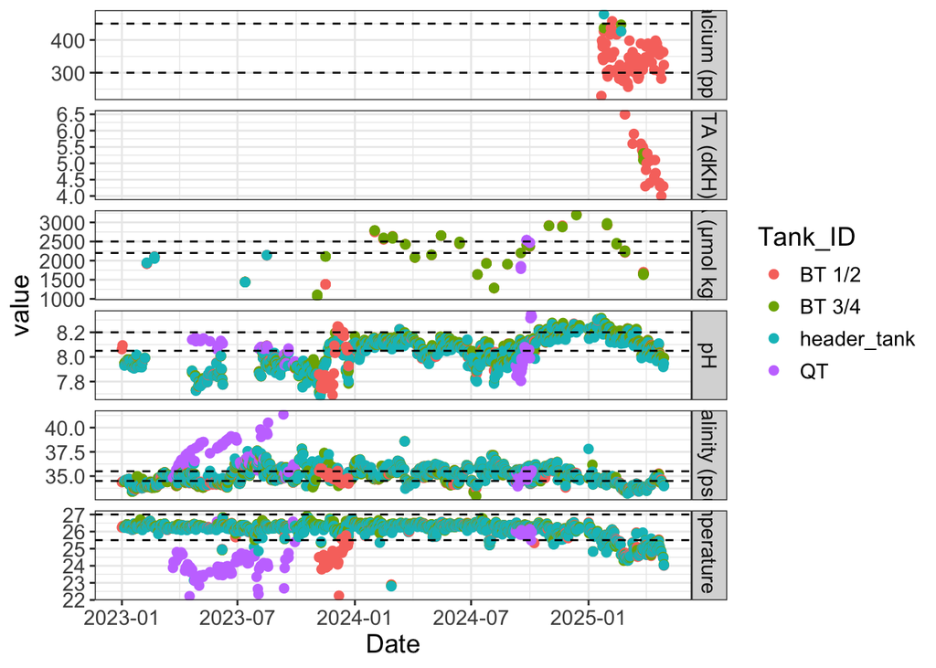

```r
facet_labels <- unique(pHSlope.long$metric)
names(facet_labels) = facet_labels
facet_labels <- replace(facet_labels, which(facet_labels == "TA"), "TA (µmol kg-1)")
facet_labels <- replace(facet_labels, which(facet_labels == "TA_dKH"), "TA (dKH)")
facet_labels <- replace(facet_labels, which(facet_labels == "Calcium_ppm"), "Calcium (ppm)")
facet_labels <- replace(facet_labels, which(facet_labels == "pH.total"), "pH")
facet_labels <- replace(facet_labels, which(facet_labels == "Salinity_psu"), "Salinity (psu)")
facet_labels <- replace(facet_labels, which(facet_labels == "Temperature_C"), "Temperature (ºC)")

daily_tank<-pHSlope.long %>%
  ggplot(aes(x=Date, y=value, colour=Tank_ID))+
  geom_point(size=2)+
  xlab("Date")+
  facet_grid(factor(metric,c("Calcium_ppm","TA_dKH","TA","pH.total","Salinity_psu","Temperature_C")) ~ ., scales = "free", labeller = as_labeller(facet_labels))+
  geom_hline(data = hlines_data[[1]], aes(yintercept = yintercept), linetype = "dashed") +
  geom_hline(data = hlines_data[[2]], aes(yintercept = yintercept), linetype = "dashed") +
  geom_hline(data = hlines_data[[3]], aes(yintercept = yintercept), linetype = "dashed") +
  geom_hline(data = hlines_data[[4]], aes(yintercept = yintercept), linetype = "dashed") +
  geom_hline(data = hlines_data[[5]], aes(yintercept = yintercept), linetype = "dashed") +
  geom_hline(data = hlines_data[[6]], aes(yintercept = yintercept), linetype = "dashed") +
  geom_hline(data = hlines_data[[7]], aes(yintercept = yintercept), linetype = "dashed") +
  geom_hline(data = hlines_data[[8]], aes(yintercept = yintercept), linetype = "dashed") +
  geom_hline(data = hlines_data[[9]], aes(yintercept = yintercept), linetype = "dashed") +
  geom_hline(data = hlines_data[[10]], aes(yintercept = yintercept), linetype = "dashed") +
  theme_bw() +
  theme(text = element_text(size = 14)); daily_tank
```

```r
# Save plot
ggsave("../Output/Daily_Measurements.pdf", daily_tank, width = 20, height = 15, units = c("in"))
```

It isn’t super informative to look at multiple years in one plot.

Filter and plot by the past six months

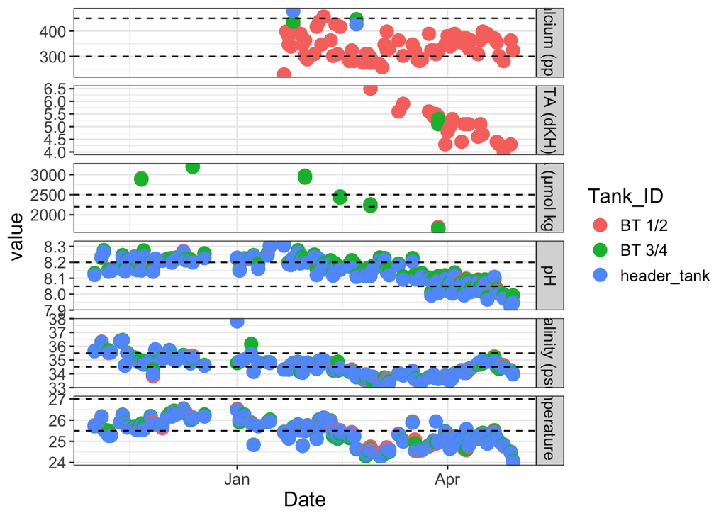

```r
# Filter to the past 180 days
daily_6month <- pHSlope.long %>%
  filter(Date >= Sys.Date() - 180)  # Adjust 30 to the number of days you want to consider

# Plot data from the past month
daily_6month_plot <- daily_6month %>%
  ggplot(aes(x=Date, y=value, colour=Tank_ID))+
  geom_point(size=4)+
  xlab("Date")+
  facet_grid(factor(metric,c("Calcium_ppm","TA_dKH","TA","pH.total","Salinity_psu","Temperature_C")) ~ ., scales = "free", labeller = as_labeller(facet_labels))+
  geom_hline(data = hlines_data[[1]], aes(yintercept = yintercept), linetype = "dashed") +
  geom_hline(data = hlines_data[[2]], aes(yintercept = yintercept), linetype = "dashed") +
  geom_hline(data = hlines_data[[3]], aes(yintercept = yintercept), linetype = "dashed") +
  geom_hline(data = hlines_data[[4]], aes(yintercept = yintercept), linetype = "dashed") +
  geom_hline(data = hlines_data[[5]], aes(yintercept = yintercept), linetype = "dashed") +
  geom_hline(data = hlines_data[[6]], aes(yintercept = yintercept), linetype = "dashed") +
  geom_hline(data = hlines_data[[7]], aes(yintercept = yintercept), linetype = "dashed") +
  geom_hline(data = hlines_data[[8]], aes(yintercept = yintercept), linetype = "dashed") +
  geom_hline(data = hlines_data[[9]], aes(yintercept = yintercept), linetype = "dashed") +
  geom_hline(data = hlines_data[[10]], aes(yintercept = yintercept), linetype = "dashed") +
  theme_bw() +
  theme(text = element_text(size = 14))
daily_6month_plot
```

```r
# Save plot
ggsave("../Output/Daily_Measurements_Past_6Months.pdf", daily_6month_plot, width = 20, height = 15, units = c("in"))
```

Filter and plot by the past month

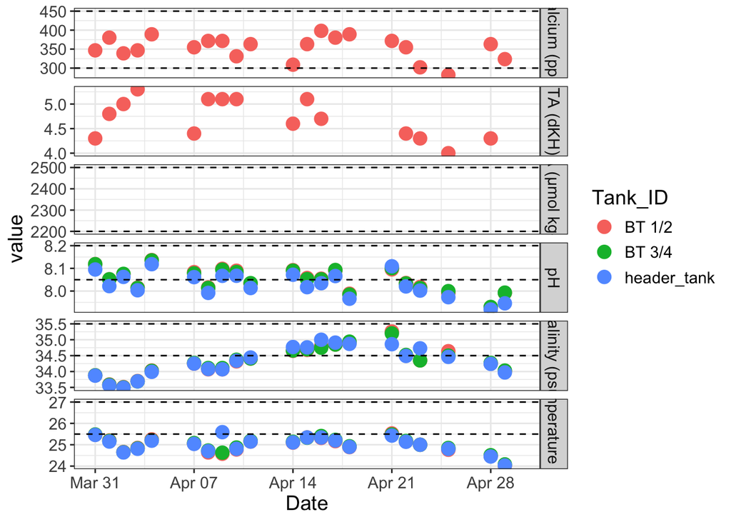

```r
# Filter to the past 30 days
daily_month <- pHSlope.long %>%
  filter(Date >= Sys.Date() - 30)  # Adjust 30 to the number of days you want to consider

# Plot data from the past month
daily_month_plot <-daily_month %>%
  ggplot(aes(x=Date, y=value, colour=Tank_ID))+
  geom_point(size=4)+
  xlab("Date")+
  facet_grid(factor(metric,c("Calcium_ppm","TA_dKH","TA","pH.total","Salinity_psu","Temperature_C")) ~ ., scales = "free", labeller = as_labeller(facet_labels))+
  geom_hline(data = hlines_data[[1]], aes(yintercept = yintercept), linetype = "dashed") +
  geom_hline(data = hlines_data[[2]], aes(yintercept = yintercept), linetype = "dashed") +
  geom_hline(data = hlines_data[[3]], aes(yintercept = yintercept), linetype = "dashed") +
  geom_hline(data = hlines_data[[4]], aes(yintercept = yintercept), linetype = "dashed") +
  geom_hline(data = hlines_data[[5]], aes(yintercept = yintercept), linetype = "dashed") +
  geom_hline(data = hlines_data[[6]], aes(yintercept = yintercept), linetype = "dashed") +
  geom_hline(data = hlines_data[[7]], aes(yintercept = yintercept), linetype = "dashed") +
  geom_hline(data = hlines_data[[8]], aes(yintercept = yintercept), linetype = "dashed") +
  geom_hline(data = hlines_data[[9]], aes(yintercept = yintercept), linetype = "dashed") +
  geom_hline(data = hlines_data[[10]], aes(yintercept = yintercept), linetype = "dashed") +
  theme_bw() +
  theme(text = element_text(size = 14))
daily_month_plot
```

```r
# Save plot
ggsave("../Output/Daily_Measurements_Past_Month.pdf", daily_month_plot, width = 20, height = 15, units = c("in"))
```

Summarize daily measurements over the past month

```r
daily_month <- pHSlope %>%
  filter(Date >= Sys.Date() - 30)  # Adjust 30 to the number of days you want to consider

summary<-daily_month%>%
  group_by(Tank_ID)%>%
  #select(!tank)%>%
  select(Temperature_C:TA) %>%
  summarise(across(everything(), list(mean = mean, sd = sd), na.rm = TRUE)); summary
```

```
## # A tibble: 3 × 13
##   Tank_ID  Temperature_C_mean Temperature_C_sd Salinity_psu_mean Salinity_psu_sd
##   <chr>                 <dbl>            <dbl>             <dbl>           <dbl>
## 1 BT 1/2                 25.0            0.368              34.3           0.459
## 2 BT 3/4                 25.0            0.350              34.3           0.450
## 3 header_…               25.0            0.368              34.3           0.462
## # ℹ 8 more variables: pH.total_mean <dbl>, pH.total_sd <dbl>,
## #   Calcium_ppm_mean <dbl>, Calcium_ppm_sd <dbl>, TA_dKH_mean <dbl>,
## #   TA_dKH_sd <dbl>, TA_mean <dbl>, TA_sd <dbl>
```